# Map Motif Models

Alex White

March 1, 2016

One way to understand the assembly of local communties is through the regional association of those species outside of the local plot at a regional spatial scale. Overlaying all of the geographic ranges of the species from the local plot yeilds a heat map where hot colors correspond to of the abundance of species in local plot which share range in each map cell. Thus in each map cell, there is a value of abundance with the maxiumum abundance limited by the total number of species in the local plot. This map is referred to as an assemblage dispersion field (ADF, Rhabek and Graves 2005).

In the context of the assemblage motif model, assemblage dispersion fields for each local plot represent the same element of the model as the local abundance distribution of species or in the case of topic modeling, the document. Just as with the taxonomic motif model, we have 35 ADFs, and an abundance of each map cell corresponsing to the number of overlapping ranges from the local species list. We can model the entire collection of these maps (the map corpus) using a topic model, and as how the underlying map “topics” or regional motifs contribute to the ADF of each local community. As well we can ask that the theta contribution of each map cell is to those regional map motifs, and plot those theta distrbutions using a heat map as well.

First we read in the data and run the topic model. However, I will merely present the results.

Below are the results for K = 2.

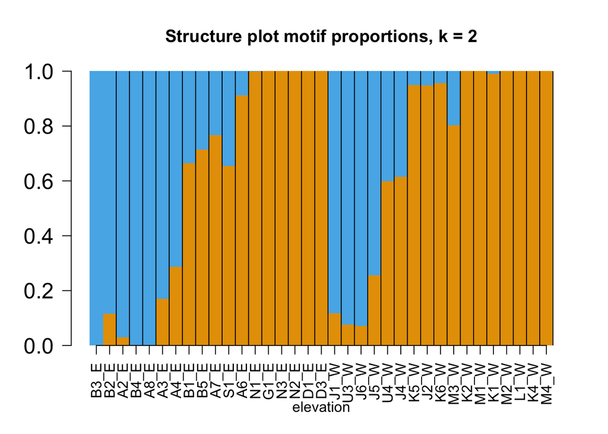

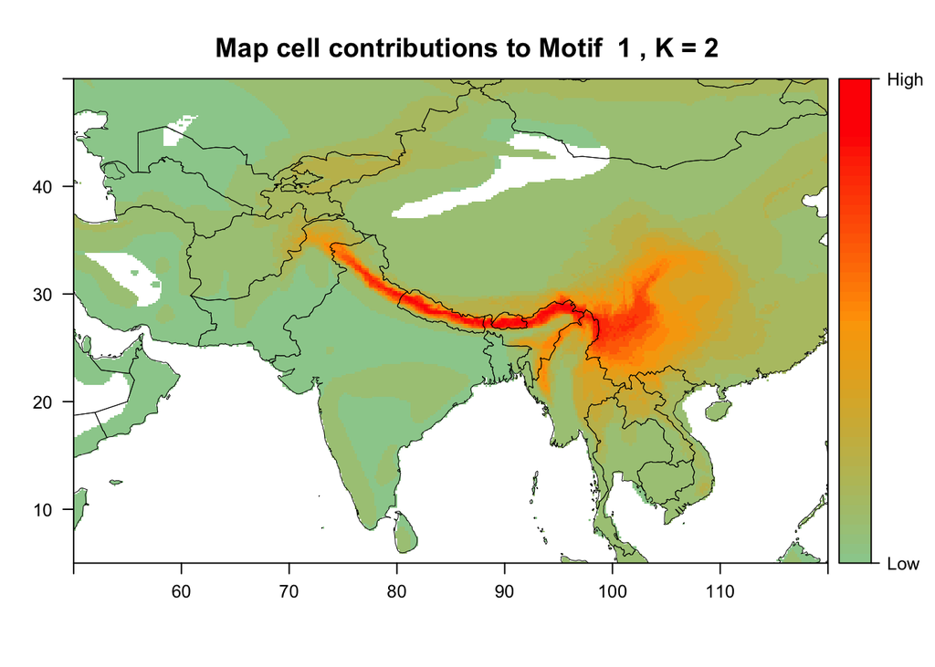

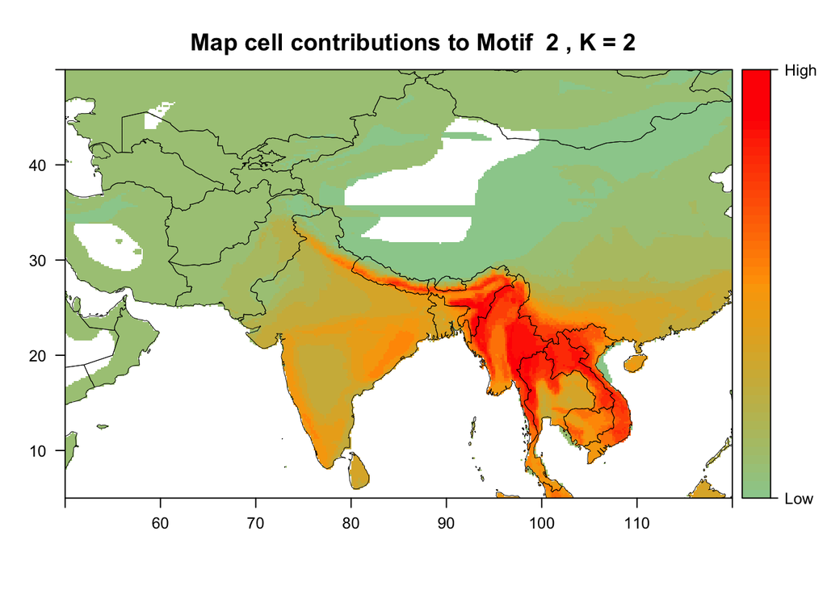

Below are the results for K = 3.

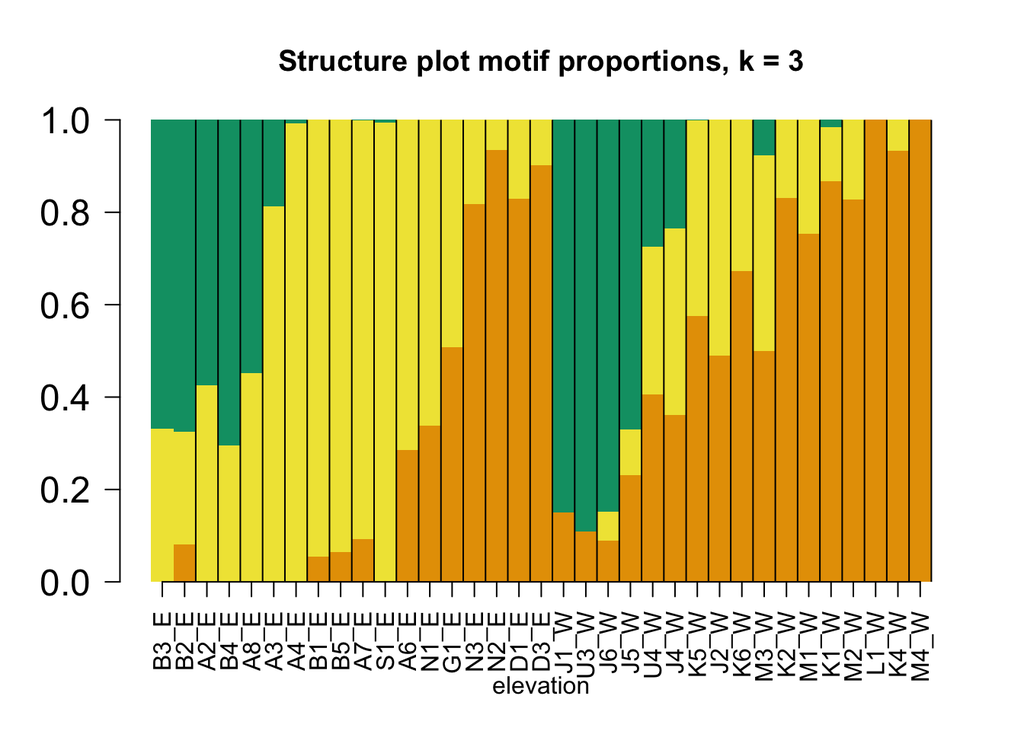

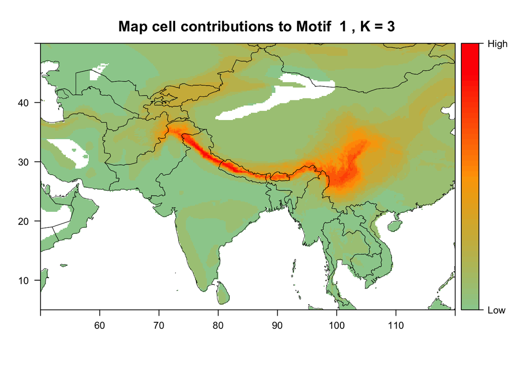

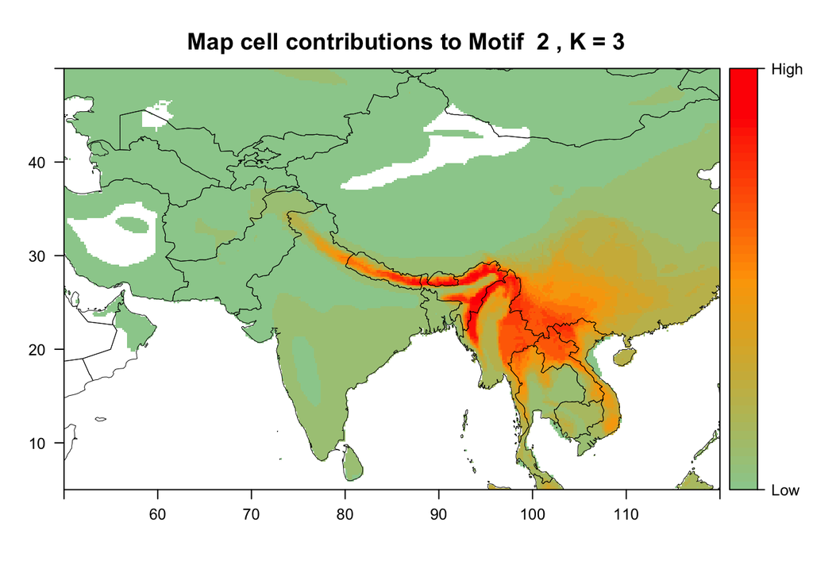

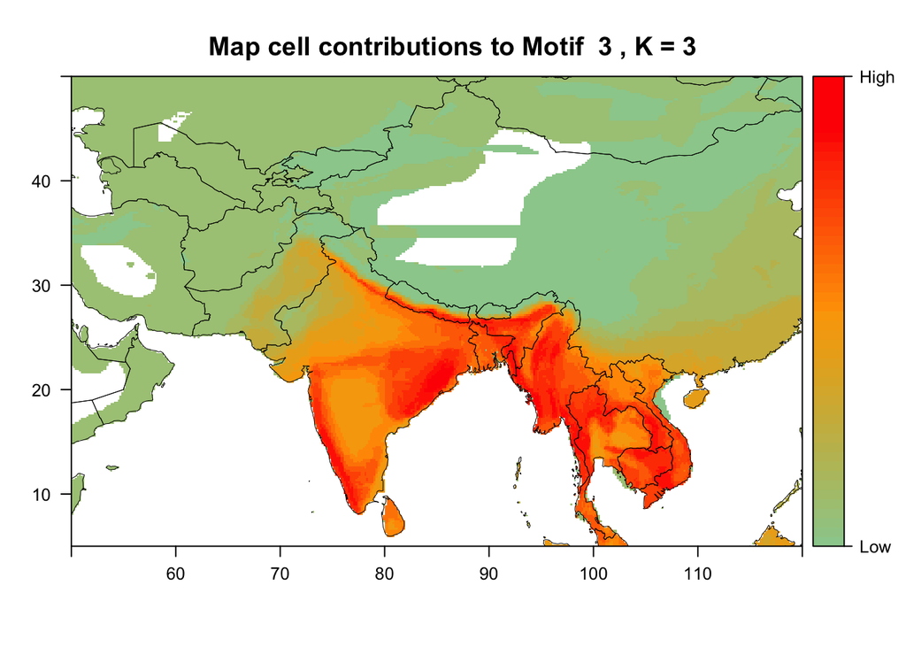

Below are the results for K = 4

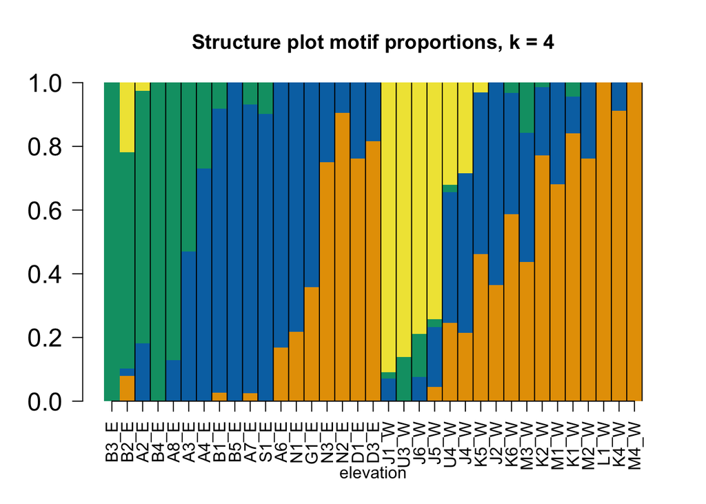

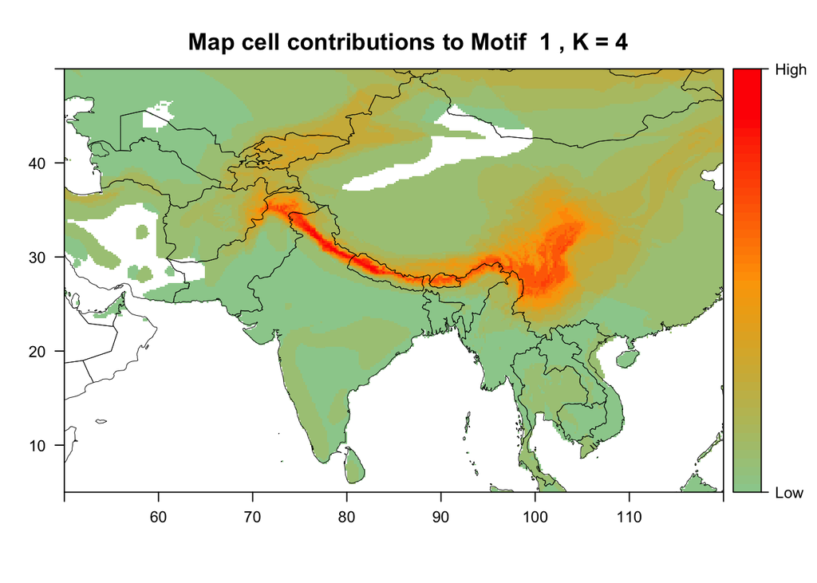

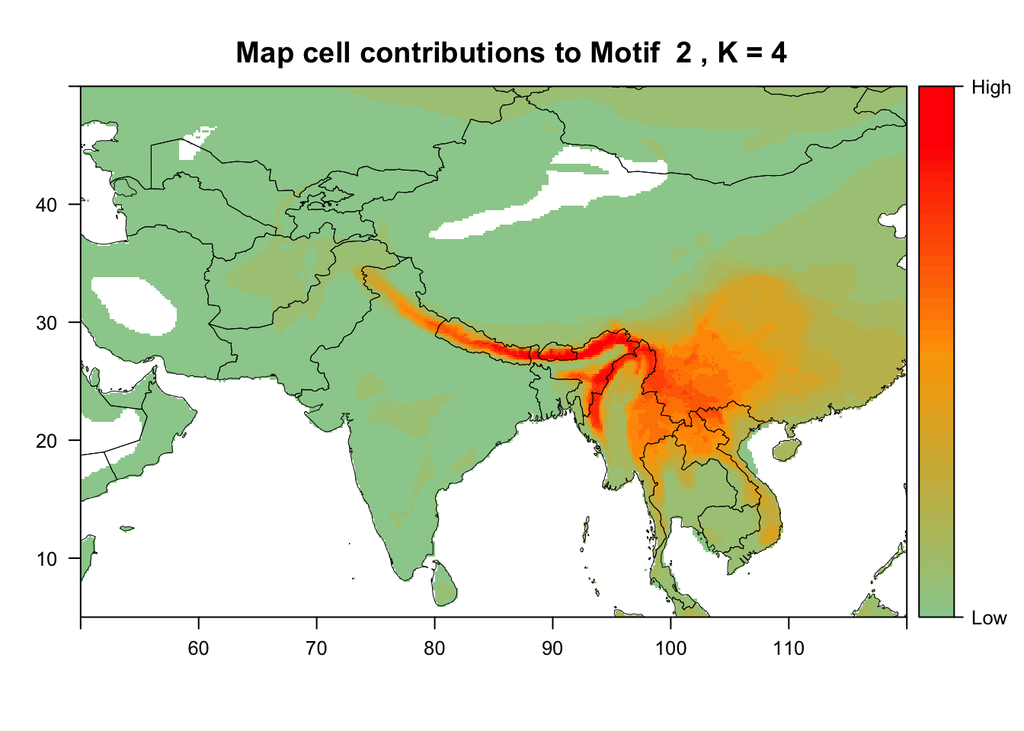

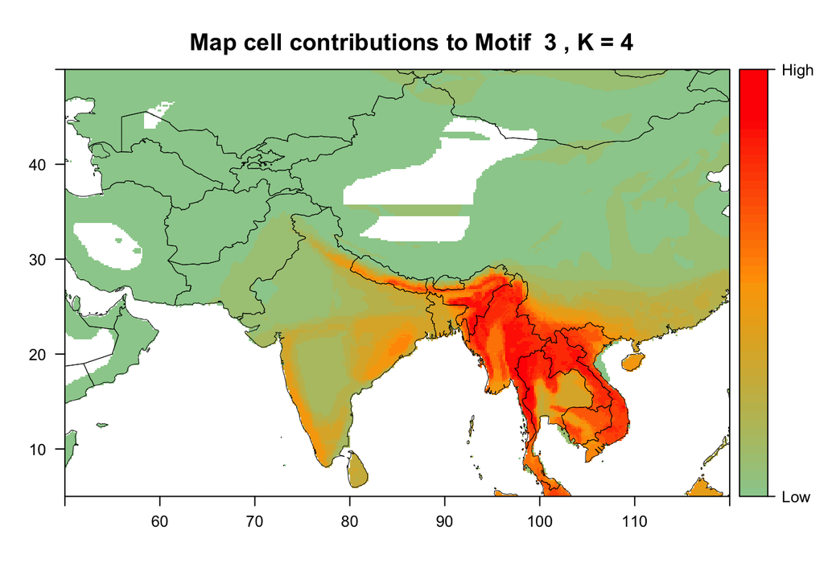

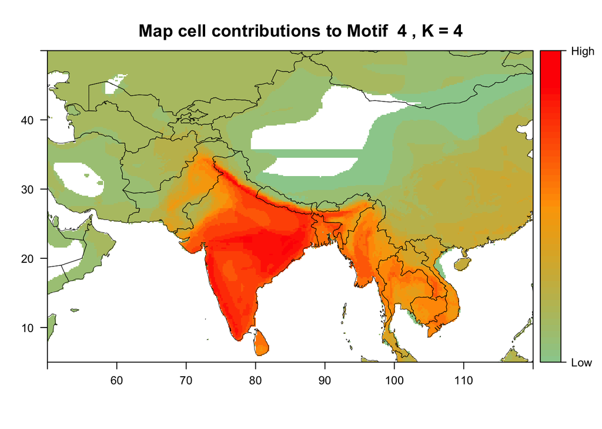